# Что важно знать гражданам Санкт-Петербурга об эпидемии коронавируса

*Алексей Куприянов* / alexei.kouprianov@gmail.com

Версия основного текста: 2021-08-25

Количественные показатели обновлены по данным на: 2021-09-04 11:00:00

## Какова в целом ситуация с эпидемией коронавируса в России и Петербурге?

Эпидемия заболевания, вызываемого вирусом SARS-CoV-2 (COVID-19, ковид — от Coronavirus Disease), началась в Китае осенью 2019 г. и через Европу проникла в Россию в начале 2020 г. Петербург был одним из первых городов России, столкнувшихся с вирусом. Первый случай в Петербурге был зарегистрирован 4 марта 2020 г. Ковид-19 — опасное, быстро распространяющееся заболевание. По предварительным оценкам специалистов его летальность (доля умерших от всех заразившихся) в невакцинированной популяции составляет около 1.0% (более, чем в десять раз опаснее сезонного гриппа). Человек, уже заразившийся коронавирусом, способен, если не приняты меры предосторожности, заразить до наступления симптомов в среднем трех человек. Штаммы, появившиеся в ходе развития эпидемии характеризуются большей заразностью (носитель штамма “Дельта” заражает до наступления симптомов и изоляции в среднем примерно в два — три раза больше людей, чем носитель исходного штамма).

Мы несем огромные потери от эпидемии. Прежде всего — в виде небывалой избыточной смертности, связанной с ковидом (см. рис. 1). С начала эпидемии в оперативном учете по России в целом было зарегистрировано 182.3 тыс. смертей от COVID-19. Действительное количество смертей, связанных с COVID-19 много выше. Точный подсчет затруднен и зависит от используемой методики, но на июль 2021 г. избыточное количество смертей по сравнению с последним “доковидным” 2019 г. составило около 582.7 тыс. человек. Только в Петербурге с начала эпидемии на июль 2021 г. от ковида умерло не менее 27.9 тыс. человек. Таким образом, потери одного, пусть и крупного, города сопоставимы с потерями СССР или России в целом в многолетних локальных вооруженных конфликтах (Афганская война 1979–1989, Первая и Вторая Чеченские войны 1994–1996 и 1999–2009) или превышают их. По сути, мы имеем дело с настоящей гуманитарной катастрофой.

**Таблица 1. Показатели смертности от COVID-19.** Данные оперативного учета смертей по странам в целом, включая Россию, взяты из ежедневно обновляемого банка данных *Johns Hopkins University*, по России они соответствуют данным Роспотребнадзора (сайт *стопкоронавирус.рф*). Данные по регионам России — из ежедневной сводки на сайте *стопкоронавирус.рф.* Оценки избыточного количества смертей для Швеции и Финляндии не приводятся, поскольку в этих странах смерти от коронавируса в полном объеме представлены в оперативном учете. Оценки избыточного количества смертей для Эстонии, Латвии и Литвы приводятся по результатам расчетов Д. Кобака, для России и ее регионов — на основании данных ресурса *ЕМИСС Государственная статистика.*

| Страна / регион | Население, млн. чел. | Плотность, чел./км2 | Умершие от COVID (оперативные данные) | Избыточные смерти к 2019 (на июль 2021) | Умерших на 100 тыс. (оперативные данные) | Умерших на 100 тыс. (к 2019 г.) |
| --- | --- | --- | --- | --- | --- | --- |
| Швеция | 10.402 | 23.10 | 14692 | NA | 141.24 | NA |
| Финляндия | 5.536 | 16.36 | 1031 | NA | 18.62 | NA |
| Эстония | 1.330 | 29.41 | 1296 | 2100 | 97.44 | 157.89 |
| Латвия | 1.908 | 29.54 | 2584 | 3600 | 135.45 | 188.71 |
| Литва | 2.784 | 42.64 | 4593 | 10000 | 164.96 | 359.16 |
| Россия | 146.171 | 8.55 | 182341 | 582747 | 124.74 | 398.67 |
| Санкт-Петербург | 5.384 | 3741.72 | 20727 | 27906 | 384.95 | 518.28 |
| Ленинградская область | 1.893 | 22.56 | 2417 | 9831 | 127.70 | 519.41 |
| Карелия | 0.609 | 3.37 | 787 | 3016 | 129.21 | 495.18 |
| Вологодская область | 1.151 | 7.96 | 1654 | 3522 | 143.70 | 305.98 |
| Новгородская область | 0.592 | 10.87 | 384 | 2520 | 64.82 | 425.38 |
| Псковская область | 0.620 | 11.20 | 691 | 2236 | 111.41 | 360.50 |

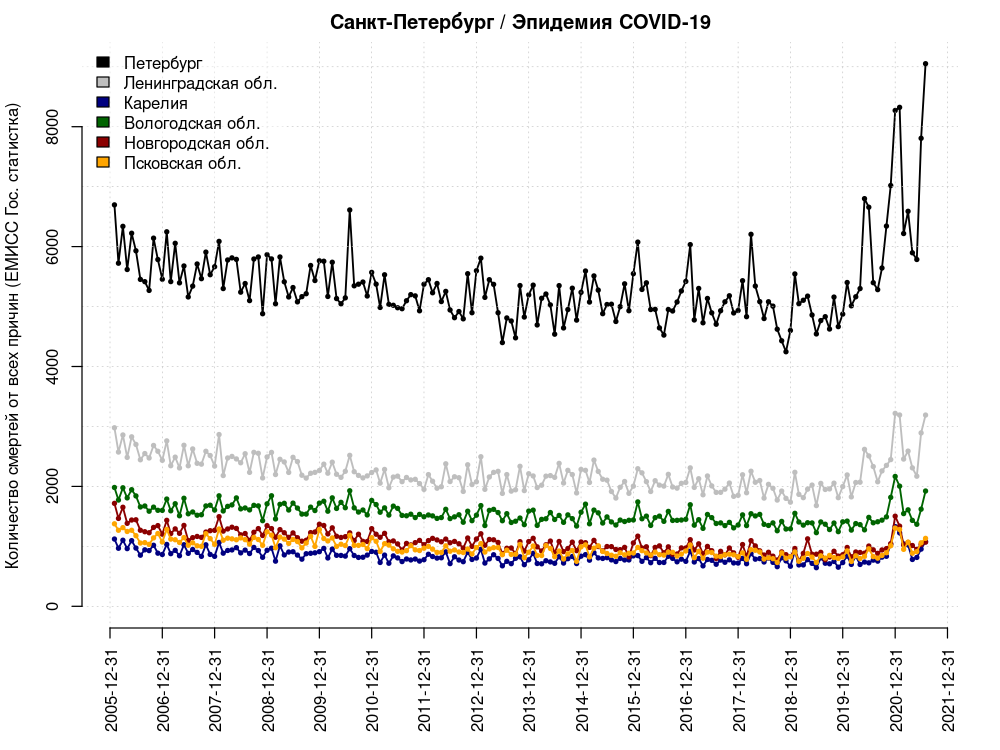

**Рис. 1. Помесячная динамика количества смертей с 2006 г. в Петербурге и сопредельных регионах России.** Обратите внимание на превышение обычного уровня смертности в 2020–2021 гг., много меньшую выраженность первой волны и запаздывание третьей волны за пределами Петербурга и Ленинградской области

## Почему гражданам важно самим следить за развитием эпидемической ситуации?

Эпидемия коронавируса — это не эпидемия чумы в средневековом городе. Трупы не лежат на улицах, система здравоохранения работает на пределе, но пока справляется, граждане могут вообще не замечать, что происходит что-то экстраординарное, пока болезнь не коснется их самих, их родственников и знакомых. Единственный инструмент, который позволяет “увидеть” эпидемию — грамотно собираемая и своевременно публикуемая медицинская статистика.

К сожалению, права граждан на получение информации в критически важном вопросе о развитии эпидемии систематически нарушаются. Большая часть истории эпидемии — история намеренных фальсификаций и попыток сокрытия данных о заболеваемости и смертности.

Так, данные по новым выявленным случаям в Петербурге по версии Роспотребнадзора с мая 2020 г. носят признаки систематической намеренной фальсификации. Они не показывают случайных колебаний день ото дня, в них отсутствуют признаки “бюрократической” динамики — резкие спады по выходным и праздничным дням, характерные для всех “честных” временных рядов медицинской статистики, пики заболеваемости отстают от пиков смертности или совпадают с ними, хотя должны опережать их приблизительно на две недели. Не имевшие признаков сознательной фальсификации данные, публиковавшиеся от имени Межведомственного городского совета по противодействию распространению коронавирусной инфекции в Петербурге с 16 декабря 2020 по 2 июня 2021 г., показывали значительные расхождения с данными в версии Роспотребнадзора. В частности, к концу мая данные городского совета показывали рост заболеваемости, числа “активных” случаев (людей, болеющих на настоящий момент) и рост нагрузки на больницы.

Опыт критических периодов трех волн эпидемии (апрель — июнь 2020, сентябрь 2020 — январь 2021, май — июль 2021) показывает, что городские власти систематически опаздывают с введением противоэпидемических мер или даже сознательно отказываются от них. Это значит, что гражданам придется самим отслеживать развитие ситуации и полагаться, в основном, на свои силы и комментарии независимых экспертов как в оценке достоверности медицинской статистики, так и в принятии решений о самоизоляции, сокращении времени пребывания в местах скопления людей, ношении масок и респираторов, вакцинации.

## Какие статистические показатели важно отслеживать?

Важнейшие показатели развития эпидемии — количество проведенных тестов, количество новых выявленных случаев заболевания и количество умерших. Последний, количество умерших, более надежен, поскольку выявить всех заболевших не представляется возможным в принципе. Вместе с тем, количество тестов также может косвенно свидетельствовать о динамике эпидемии.

Отслеживать тенденции к росту и спаду бывает непросто, поскольку числа колеблются день ото дня даже на устойчивом подъеме или спаде. Два самых простых способа сгладить случайные колебания и увидеть тенденцию — это, во-первых, суммирование данных по неделям, во-вторых — расчет “скользящих” средних. Чаще всего применяют семидневные скользящие средние (для каждого дня берут значения за сам этот день, три дня до него и три дня после него).

## Какие источники информации заслуживают доверия?

Все наиболее важные источники данных по ситуации в России и Петербурге со всеми необходимыми ссылками собраны в отдельном документе “Основные источники данных по эпидситуации c COVID-19 в Санкт-Петербурге”. Подробный анализ фальсификаций и умолчаний опубликован в отдельном документе “Критический анализ показателей эпидемической статистики”.

Наиболее надежным оперативным показателем остаются данные учета смертей, связанных с ковид, ежедневно публикуемые на сайте “стопкоронавирус.рф”, а также данные о числе проведенных тестов на коронавирус и о госпитализации, с 3 августа ежедневно публикуемые на портале [“Петербург против коронавируса. Официальная информация”](https://www.gov.spb.ru/covid-19/). В отношении полного учета общей смертности важны публикуемые с задержкой данные Росстата по Естественному движению населения (в месяцы, на которые приходится пик волны, оперативный учет не успевает отражать все случаи). По ним можно отслеживать развитие эпидемии в ретроспективе помесячно. Данные публикуются с приблизительно сорокадневной задержкой (данные за январь публикуют в конце первой — второй недели марта и т. д.).

Остальные официально публикуемые данные (количество новых случаев и количество выздоровевших по версии сайта “стопкоронавирус.рф”) в той или иной степени искажены и не могут быть бездумно использованы для оценки ситуации.

Сводные отчеты о ситуации в Петербурге с учетом всех возможных открытых источников можно найти на нашем сайте. Кроме того, каждый сможет скачать данные, на основе которых составляются эти отчеты, и, при желании, самостоятельно произвести все необходимые вычисления и построить графики.

- Скачать сводные данные по Петербургу (по дням) SPb.COVID-19.united.csv
- Скачать описание переменных в файле `SPb.COVID-19.united.csv`
- Скачать данные по поисковым запросам Яндекса SPb.yandex_wordstat.weekly.csv
- Скачать данные по общему количеству умерших помесячно с 2006 г. (выгрузка из ЕМИСС Государственная статистика) для России, Петербурга и сопредельных регионов SPb.adjacent_regions.all_deaths.2006_.csv

Данные, тексты и инфографика размещены в этом репозитории на условиях лицензии Creative Commons Attribution-ShareAlike 4.0 International ([CC BY-SA 4.0](https://creativecommons.org/licenses/by-sa/4.0/)).